# Predictive Model For Determining Fitness Exercise Correctness

Bui Dinh Ngoc

February 29, 2016

- Repo URL : https://github.com/ngocbd/Practical-Machine-Learning/
- Pages URL : http://ngocbd.github.io/Practical-Machine-Learning/

### Predictive Model For Determining Fitness Exercise Correctness

## Introduction

Using devices such as Jawbone Up, Nike FuelBand, and Fitbit it is now possible to collect a large amount of data about personal activity relatively inexpensively. These type of devices are part of the quantified self movement a group of enthusiasts who take measurements about themselves regularly to improve their health, to find patterns in their behavior, or because they are tech geeks. One thing that people regularly do is quantify how much of a particular activity they do, but they rarely quantify how well they do it. In this project, your goal will be to use data from accelerometers on the belt, forearm, arm, and dumbell of 6 participants. They were asked to perform barbell lifts correctly and incorrectly in 5 different ways.

In this reasearch, I build a predictive model to determine whether a particular form of exercise (barbell lifting) is performed correctly. More information is available from the website here: http://groupware.les.inf.puc-rio.br/har (see the section on the Weight Lifting Exercise Dataset).

## Getting Data

```r
if (! file.exists('pml-training.csv')) {
    download.file('http://d396qusza40orc.cloudfront.net/predmachlearn/pml-training.csv',destfile = 'pml-training.csv')
}
if (! file.exists('pml-testing.csv')) {
    download.file('http://d396qusza40orc.cloudfront.net/predmachlearn/pml-testing.csv',destfile = 'pml-testing.csv')
}

pmltraining <- read.csv('pml-training.csv')
pmltesting <- read.csv('pml-testing.csv')
```

## Cleaning Data

Only choose some useful data :

```r
cols <- c('roll_belt', 'pitch_belt', 'yaw_belt', 'total_accel_belt',
                  'gyros_belt_x', 'gyros_belt_y', 'gyros_belt_z',
                  'accel_belt_x', 'accel_belt_y', 'accel_belt_z',
                  'magnet_belt_x', 'magnet_belt_y', 'magnet_belt_z',
                  'roll_arm', 'pitch_arm', 'yaw_arm', 'total_accel_arm',
                  'gyros_arm_x', 'gyros_arm_y', 'gyros_arm_z',
                  'accel_arm_x', 'accel_arm_y', 'accel_arm_z',
                  'magnet_arm_x', 'magnet_arm_y', 'magnet_arm_z',
                  'roll_dumbbell', 'pitch_dumbbell', 'yaw_dumbbell', 'total_accel_dumbbell',
                  'gyros_dumbbell_x', 'gyros_dumbbell_y', 'gyros_dumbbell_z',
                  'accel_dumbbell_x', 'accel_dumbbell_y', 'accel_dumbbell_z',
                  'magnet_dumbbell_x', 'magnet_dumbbell_y', 'magnet_dumbbell_z',
                  'roll_forearm', 'pitch_forearm', 'yaw_forearm', 'total_accel_forearm',
                  'gyros_forearm_x', 'gyros_forearm_y', 'gyros_forearm_z',
                  'accel_forearm_x', 'accel_forearm_y', 'accel_forearm_z',
                  'magnet_forearm_x', 'magnet_forearm_y', 'magnet_forearm_z'
                  )
pmltesting <- pmltesting[, cols]
cols <- c(cols, 'classe')
pmltraining <- pmltraining[, cols]
```

## Data split traning and validate set

```r
echo = FALSE
library(randomForest)
library(caret)
validateIndex <- createDataPartition(y=pmltraining$classe, p=0.8, list=FALSE)
pmltraining <- pmltraining[validateIndex,]
validate <- pmltraining[-validateIndex,]
```

## Predictive Model

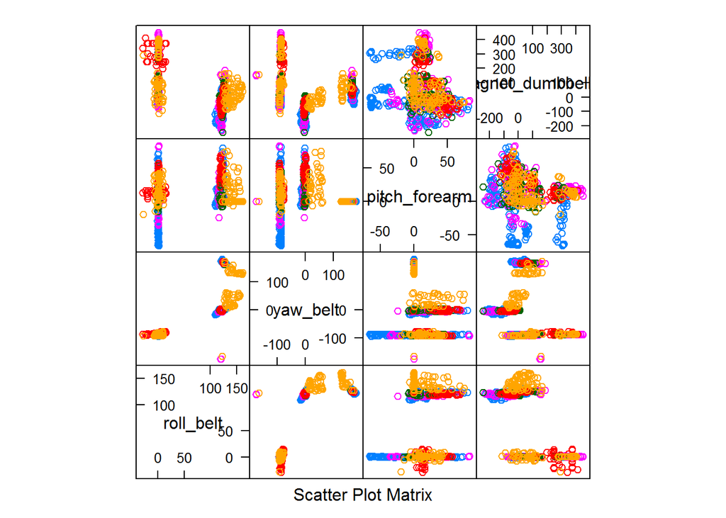

```r
set.seed(1984)
model <- randomForest(classe ~ ., data = pmltraining, ntree=2000, importance = T)
imp = data.frame(model$importance)
features = order(-imp$MeanDecreaseGini)
inImp = createDataPartition(pmltraining$classe, p = 0.05, list = F)
featurePlot(pmltraining[inImp,features[1:4]],pmltraining$classe[inImp], plot = "pairs")
```

```r
importanceOnlyModel <- randomForest(classe ~ pitch_belt+yaw_belt+total_accel_belt+gyros_belt_x, data = pmltraining, ntree=2000, importance = T)
```

### Predict

```r
predict(model, pmltesting)
```

```
##  1  2  3  4  5  6  7  8  9 10 11 12 13 14 15 16 17 18 19 20
##  B  A  B  A  A  E  D  B  A  A  B  C  B  A  E  E  A  B  B  B
## Levels: A B C D E
```

```r
predict(importanceOnlyModel, pmltesting)
```

```
##  1  2  3  4  5  6  7  8  9 10 11 12 13 14 15 16 17 18 19 20
##  B  A  B  C  E  E  D  A  A  A  B  C  B  C  E  E  A  B  B  B
## Levels: A B C D E
```

### Cross validation

```r
confusionMatrix(validate$classe, predict(model,validate))
```

```
## Confusion Matrix and Statistics
##
##           Reference
## Prediction   A   B   C   D   E
##          A 908   0   0   0   0
##          B   0 594   0   0   0
##          C   0   0 529   0   0
##          D   0   0   0 532   0
##          E   0   0   0   0 579
##
## Overall Statistics
##
##                Accuracy : 1
##                  95% CI : (0.9988, 1)
##     No Information Rate : 0.289
##     P-Value [Acc > NIR] : < 2.2e-16
##
##                   Kappa : 1
##  Mcnemar's Test P-Value : NA
##
## Statistics by Class:
##
##                      Class: A Class: B Class: C Class: D Class: E
## Sensitivity             1.000   1.0000   1.0000   1.0000   1.0000
## Specificity             1.000   1.0000   1.0000   1.0000   1.0000
## Pos Pred Value          1.000   1.0000   1.0000   1.0000   1.0000
## Neg Pred Value          1.000   1.0000   1.0000   1.0000   1.0000
## Prevalence              0.289   0.1891   0.1684   0.1693   0.1843
## Detection Rate          0.289   0.1891   0.1684   0.1693   0.1843
## Detection Prevalence    0.289   0.1891   0.1684   0.1693   0.1843
## Balanced Accuracy       1.000   1.0000   1.0000   1.0000   1.0000
```

```r
confusionMatrix(validate$classe, predict(importanceOnlyModel,validate))
```

```
## Confusion Matrix and Statistics
##
##           Reference
## Prediction   A   B   C   D   E
##          A 898   1   7   1   1
##          B   2 590   1   1   0
##          C   5   4 513   7   0
##          D   3   0   1 528   0
##          E   1   0   0   1 577
##
## Overall Statistics
##
##                Accuracy : 0.9885
##                  95% CI : (0.9842, 0.992)
##     No Information Rate : 0.2893
##     P-Value [Acc > NIR] : < 2.2e-16
##
##                   Kappa : 0.9855
##  Mcnemar's Test P-Value : NA
##
## Statistics by Class:
##
##                      Class: A Class: B Class: C Class: D Class: E
## Sensitivity            0.9879   0.9916   0.9828   0.9814   0.9983
## Specificity            0.9955   0.9984   0.9939   0.9985   0.9992
## Pos Pred Value         0.9890   0.9933   0.9698   0.9925   0.9965
## Neg Pred Value         0.9951   0.9980   0.9966   0.9962   0.9996
## Prevalence             0.2893   0.1894   0.1661   0.1712   0.1840
## Detection Rate         0.2858   0.1878   0.1633   0.1680   0.1836
## Detection Prevalence   0.2890   0.1891   0.1684   0.1693   0.1843
## Balanced Accuracy      0.9917   0.9950   0.9883   0.9899   0.9987
```